# Simple C++ calculation

For this first workshop we will be considering a simple mathematical calculation of the *Mandelbrot set* implemented in C++ as `mandelbrot.cpp`. This code generated the data plotted in Figure 1 below. It is **not** necessary for you to understand or modify this C++ code today, **nor** is it essential you have an in-depth understanding of the mathematics of this example. We will be learning much more about the syntax and functionality of C++ code over the next few workshops.

The Mandelbrot set calculation is a classic example of an embarrassingly parallel computation. After this workshop you are invited to try out the **optional** activity Using HPC where the same calculation is performed exploiting parallelism with HPC resources.

## Computing the Mandelbrot set

The shape of the Mandelbort set on the complex plane is a famous example of a *fractal* – a never-ending pattern of self-similar structures across all length scales.

Specifically, the Mandelbrot set is the set of complex numbers $c = c_x + {\rm i}c_y$ for which the orbit of the origin under iteration of the quadratic map
$$z_{n+1} = z_n^2 + c,
\tag{1}$$
remains bounded. So if $c$ is inside the Mandelbrot set then starting from $z_0 = 0$ and repeatedly applying the iteration $|z_n|$ does not diverge with increasing $n$. In practise we usually require that $|z_n| \leq 2$ as a criterion for being bounded.

Let’s decompose this calculation in steps:

- Choose a suitable region of the complex plane $x + {\rm i}y$ to examine – the $3 \times 3$ square $-2 \leq x \leq 1$ and $-1.5 \leq y \leq 1.5$ is convenient.
- Sample $N \times N$ points $c$ in this region, each of which will form a pixel of the final image of the set.
- For each pixel iterate the Mandelbrot mapping in Equation 1. Remember that $z_n$ is complex so $z_n = x_n + {\rm i}y_n$ means that $z_n^2 = x_n^2 - y_n^2 + 2{\rm i}x_ny_n$.
- The iteration terminates if $|z_n|>2$, which we take as a signal that the point $c$ lies outside the set. We count the number of iterations $q(c)$ taken before this condition was met and store it for each point $c$ tested.
- To prevent the iteration running endlessly we also terminate if $n(c) = D$ where $D$ is the maximum iteration count or depth we allow. Points $c$ where $n(c)$ reaches $D$ are deemed to lie inside the Mandelbrot set since they did not diverge for the depth we tested.

From this description there are two parameters $N$ and $D$ which determine the resolution of our calculation. Evidently, the larger $N$ is the more we will be able to resolve tiny structure in the set missed if we sample too coarsely. Less obvious is that increasing $D$ also determines how precise the image will be. Some points very close to the set may not meet the divergence condition $|z_n| >2$ until many iterations $q > D$ have been made, so we will incorrectly identify them as inside the set. The interesting feature of this calculation for our purposes is that we can make its computational requirements arbitrarily demanding by increasing $N$ and $D$ and obtain new increasingly complicated and beautiful images. Our aim in this workshop will be to generate a Mandelbrot image of sufficiently resolution and depth. To reach super high resolution images distributing the task over a HPC resource makes sense.

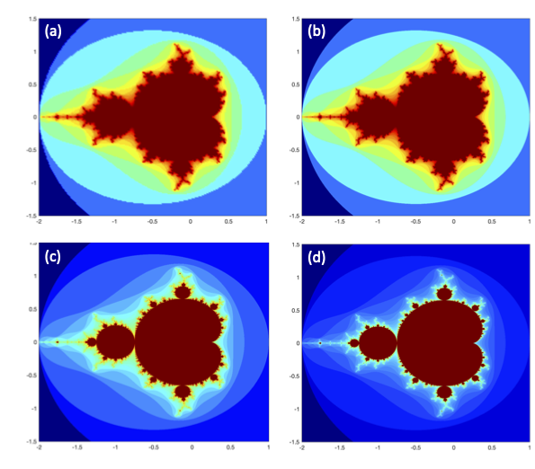

Figure 1: The Mandelbrot set computed using (a) $N=200$, $D=20$, (b) $N=2000$, $D=20$, (c) $N=2000$, $D=200$, (d) $N=2000$, $D=2000$. The colourmap is based on $\log_{10}n(c)$ so solid red signifies a point is inside the set, while blue signifies rapid divergence relative to $D$ and colours in between close to the boundary are divergences that occur only after a significant number of iterations.

Some example images of the Mandelbrot set are shown in Figure 1. The panels (a) to (d) show how increasing $N$ and $D$ alter the resolution and clarity of the image. The best of these pictures highlights some interesting properties of the Mandelbrot set. First, it is a connected set, meaning there is always a path from one point in the set to any other point which traverse only through points in the set. Second, the Mandelbrot set has a finite area but an infinite length perimeter (this curious property is related to the conundrum of what the length of the UK’s coastline actually is if one includes nooks, crannies and crevices in the rocks on all size scales). Third, the set is symmetric about the real axis so if $c$ is in the set then so is its conjugate $c^*$.

## C++ implementation

Here we introduce a C++ implementation of the Mandelbrot set calculation described above. The purpose of this code today is to provide a simple but interesting example for you to try out compiling, running and processing output as would be performed for any serious scientific calculation.

The code itself is relatively short and is listed here:

```cpp
// C++ implementation for Mandelbrot set fractals

// To avoid warnings tell the compiler to use a recent standard of C++:
// g++ -std=c++17 mandelbrot.cpp -o mandelbrot
// ./mandelbrot 1 20 20 1

#include <iostream>
#include <fstream>
#include <string>
#include <cmath>

using std::cout, std::endl;

// Function to compute if a point is inside the Mandelbrot set:
int mandelbrot(double cx, double cy, int D)
{
    double zx = 0.0, zy= 0.0; // Starting point is the origin.
    double Zx, Zy; // Intermediate complex number.
    int count = 0; // Iteration counter.

    // If the distance from the origin is greater than 2
    // AND the maximum of iterations D is reached, then exit the loop:
    while ((zx*zx + zy*zy < 4) && (count < D)) {
        // Calculate Mandelbrot function Z = z*z + c, where z is a complex number:
        Zx = zx*zx - zy*zy + cx; // Real part of Z.
        Zy = 2*zx*zy + cy; // Imaginary part of Z.

        // Update z as Z and iterate:
        zx = Zx;
        zy = Zy;

        count++; // Increment the iteration counter
    }
    return count;
}

// USAGE:   mandelbrot N, P, D, n
// N = number of boxes in the complex plane as N x N
// P = points in each box as P x P
// D = depth of calculation as the maximum iteration count
// n = 1, 2, ..., N*N, the number of the box to be computed
// OUTPUT:  fractal_data_<n>.csv

int main(int argc, char** argv)
{
    double cx, cy; // Coordinates used in main loop.
    int count; // Counter used in main loop.

    // Checking if number of argument is equal to 4 or not.
    if (argc < 4 || argc > 5) {
        cout << "ERROR: need 4 input arguments - mandelbrot N P D n" << endl;
        return 0;
    }

    // Convert command line inputs from strings to integers:
    int N = atoi(argv[1]);
    int P = atoi(argv[2]);
    int D = atoi(argv[3]);
    int n = atoi(argv[4]);

    // Fixed total box for computing fractal image is 3x3 with
    // bottom left corner at (-2,-1.5).
    double x0 = -2;
    double y0 = -1.5;
    double d = 3.0/(N*P-1); // Pixel size d x d.

    // Determine which box along the x and y axis the fractal is to be computed in:
    int nx = n % N;
    int ny = floor((n-1)/N);
    // Corresponding coordinates of the bottom left corner of the box:
    double left = d*P*nx + x0;
    double bottom = d*P*ny + y0;

    std::string filename = "fractal_data_"; // Fixed filename prefix.
    filename += std::to_string(n); // Append the box number to the data file.
    filename += ".csv"; // Save as a comma separated value text file.
    std::ofstream myfile (filename);
    if (myfile.is_open()) {
        // Scanning every point in the box:
        for (int x=0; x<P; x++) {
            for (int y=0; y<P; y++) {
                // Coordinate of constant c
                cx = x*d + left; // Real part of c.
                cy = y*d + bottom; // Imaginary part of c.

                // Iterate z = z*z + c with starting point at the origin:
                count = mandelbrot(cx,cy,D);
                // Save data as a line in a comma separated text file:
                myfile << cx << "," << cy << "," << count << endl;
            }
        }
        myfile.close();
        cout << "Mandelbrot set computation complete" << endl;
    }
    else cout << "Unable to open file" << endl;

    return EXIT_SUCCESS;
}
```

It performs precisely the calculation of the Mandelbrot set as outlined in the last section.

## Compiling and running the code

In the `bash` terminal We now compile this code using the GNU C-compiler as:

```
g++ -std=c++17 mandelbrot.cpp -o mandelbrot
```

This command should run without any output or errors if your terminal is currently located at the same directory you put the code. Should you examine the contents of the directory after compilation you will find a file `mandelbrot` present. This is the executable binary for the compiled C++ code.

The code accepts four command-line arguments of the form `mandelbrot N P D n`. where `N` is the partitioning of the complex plane into `N` $\times$ `N`boxes. When running on your own computer we will only ever use `N=1` box. The parameter `P` then specifies that each box is to be divide into `P` $\times$ `P` points. Thus we are sampling the $3 \times 3$ square of the complex plane with `NP` $\times$ `NP` points in total. Each point is computed to a maximum of `D` iteration depth. Finally, the parameter `n` specifies which of the $1,2,\dots,$ `N`$^2$ boxes this particular instances of the code is to compute.

We can test that the Mandelbrot code runs by typing:

```
./mandelbrot 1 20 20 1
```

```
Mandelbrot set computation complete
```

which specifies that it uses just 1 box with a $20\times 20$ grid, an iteration depth of 20 and computes the points inside 1 box. When the code finishes you will find a file `fractal_data_1.csv` has appeared in your directory. You can examine its contents using the `more` command as

```
more fractal_data_1.csv
```

```
-2,-1.5,1
-2,-1.34211,1
-2,-1.18421,1
-2,-1.02632,1
-2,-0.868421,1
-2,-0.710526,1
-2,-0.552632,1
-2,-0.394737,1
-2,-0.236842,1
-2,-0.0789474,1
-2,0.0789474,1
-2,0.236842,1
-2,0.394737,1
-2,0.552632,1
-2,0.710526,1
-2,0.868421,1
-2,1.02632,1
-2,1.18421,1
-2,1.34211,1
-2,1.5,1
-1.84211,-1.5,1
-1.84211,-1.34211,1
-1.84211,-1.18421,1
fractal_data_1.csv
```

where scrolling down and exiting just like with the manual pages earlier. As promised the data is saved in the format where each row stores $c_x, c_y, n(c)$ with the filename `fractal_data_1.csv`. $\Box$